# IE - Master in Business Analytics and Big Data

Recommendation Systems

Building a Non Personalized Recommendation Engine

Author: Cedric Viret

========================================================

# Initialization

Import libraries

```r
library(readr)
library(dplyr)
```

```r
library(ggplot2)
library(data.table)
library(tidyr)
library(tidyverse)
```

Load the critics dataset.

```r
data <- read_csv("critics.csv")
```

Data overview:

```r
glimpse(data)
```

```
## Observations: 20
## Variables: 21
## $ User                                <chr> "John", "Maria", "Anton", ...
## $ `Star Wars IV - A New Hope`         <int> 1, 5, NA, NA, 4, 2, NA, 4,...
## $ `Star Wars VI - Return of the Jedi` <int> 5, 3, NA, 3, 3, 4, NA, NA,...
## $ `Forrest Gump`                      <int> 2, NA, NA, NA, 4, 4, 3, NA...
## $ `The Shawshank Redemption`          <int> NA, 2, 5, NA, 1, 4, 1, NA,...
## $ `The Silence of the Lambs`          <int> 4, 4, 2, NA, 4, NA, 1, 3, ...
## $ Gladiator                           <int> 4, 2, NA, 1, 1, NA, 4, 2, ...
## $ `Toy Story`                         <int> 2, 1, 4, 2, NA, 3, NA, 2, ...
## $ `Saving Private Ryan`               <int> 2, NA, NA, 3, 4, 1, 5, NA,...
## $ `Pulp Fiction`                      <int> NA, NA, NA, 4, NA, 4, 2, 3...
## $ `Stand by Me`                       <int> 3, 4, 1, NA, 1, 4, NA, NA,...
## $ `Shakespeare in Love`               <int> 2, 3, NA, NA, 5, 5, 1, NA,...
## $ `Total Recall`                      <int> NA, 2, 1, 4, 1, 2, NA, 2, ...
## $ `Independence Day`                  <int> 5, 2, 4, 1, NA, 4, NA, 3, ...
## $ `Blade Runner`                      <int> 2, NA, 4, 3, 4, NA, 3, 2, ...
## $ `Groundhog Day`                     <int> NA, 2, 1, 5, NA, 1, NA, 4,...
## $ `The Matrix`                        <int> 4, NA, 1, NA, 3, NA, 1, NA...
## $ `Schindler's List`                  <int> 2, 5, 2, 5, 5, NA, NA, 1, ...
## $ `The Sixth Sense`                   <int> 5, 1, 3, 1, 5, 3, NA, 3, N...
## $ `Raiders of the Lost Ark`           <int> NA, 3, 1, 1, NA, NA, 5, 5,...
## $ Babe                                <int> NA, NA, 3, 2, NA, 2, 2, NA...
```

- Having a quick look at the data, it seems that there are a lot of NA value per movie. I assume that NA values mean one did not rated the movie or did not see it; thus, NA does not mean missing values.
- The data are in tansactional fromat and not tabular format; I might change (transpose) the format to answer some of the questions questions.
- Quick definition between tabular and transactional tables:[tabular vs transactional](https://www.ibm.com/support/knowledgecenter/en/SS6A3P_7.0.0/com.ibm.spss.dm.userguide.doc/dms_build_model_association_tabvstrans.htm)

# 1) Top 5 Movies, by rating mean

Calculate mean rating for each movie, ordered with the highest rating listed first, and plot the top 5.

**Expected result**: 3.600000, ‘The Shawshank Redemption’ 3.266667, ‘Star Wars IV - A New Hope’ 3.222222, ‘Blade Runner’ 3.166667, ‘Groundhog Day’ 3.062500, ‘The Silence of the Lambs’

```r
col_number = NCOL(data) ##Find the columns numbers: 21

#Finding columns' mean:
movie_mean = colMeans(subset(data,select=  c(2:col_number)), na.rm = T)
```

I have the means of all the movies, I could just return the top5 to answer the questions. However, I perfer to have the infomation into a dataframe rather that a vector (easier to read).

- Transforming a vector into a dataframe
- Getting the top5 of the dataframe

```r
# transfrom the vector into a df
df_movie_mean = data.table(as.data.frame(movie_mean), keep.rownames = T)

# by defauft the the column name will rn: I will change it to 'movie_title'
df_movie_mean = df_movie_mean %>% rename(movie_title = rn)

# Gettting the top5 (using dplyr)
top5 = df_movie_mean %>% select(movie_mean, movie_title) %>% arrange(desc(movie_mean)) %>%head(5)

#print result
print(top5)
```

```
##   movie_mean               movie_title
## 1   3.600000  The Shawshank Redemption
## 2   3.266667 Star Wars IV - A New Hope
## 3   3.222222              Blade Runner
## 4   3.166667             Groundhog Day
## 5   3.062500  The Silence of the Lambs
```

Plotting the top5

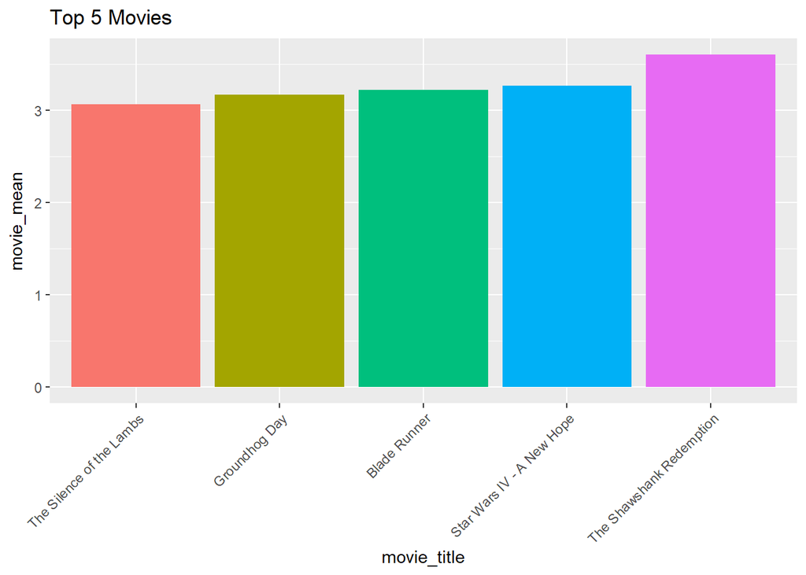

```r
# pregraph transformation:
top5$movie_title <- reorder(top5$movie_title, top5$movie_mean) ## the columns in ascending order

#plot

graph_top5 = ggplot(data = top5) + geom_col(aes(x = movie_title, y= movie_mean, fill =movie_title), show.legend = F) + labs(title = "Top 5 Movies") + theme(axis.text.x = element_text(angle = 45, hjust = 1))

#print result:
print(graph_top5)
```

Create a function that return the top 5:

```r
#return the top5:
ftop5 = function(data,value_to_sort_on){
  data = rename(data[, c(2,1)], movie_title = rn) ##rename the column rt and change the column order
  data = head(data[order(-data[,1])], n = 5) ##descending top5
  }
```

# 2) Top 5 Movies, by rating distribution

Calculate the percentage of ratings for each movie that are 4 stars or higher. Order with the highest percentage first, and plot the top 5 movies with more high ratings distribution.

**Expected result**: 0.7000000, ‘The Shawshank Redemption’ 0.5333333, ‘Star Wars IV - A New Hope’ 0.5000000, ‘Gladiator’ 0.4444444, ‘Blade Runner’ 0.4375000, ‘The Silence of the Lambs’

Finding all ratios

```r
ratio = sapply(data[2:col_number] , function(x){ sum(x == 4 | x == 5, na.rm = T) / length(x[!is.na(x)])}, simplify = T )
df_ratio = data.table(as.data.frame(ratio), keep.rownames = T) #transform in a dataframe
```

Top5 ratios

```r
#calling ftop5 function:
top5ratio = ftop5(df_ratio)

#print top5ratio
print(top5ratio)
```

```
##        ratio               movie_title
## 1: 0.7000000  The Shawshank Redemption
## 2: 0.5333333 Star Wars IV - A New Hope
## 3: 0.5000000                 Gladiator
## 4: 0.4444444              Blade Runner
## 5: 0.4375000  The Silence of the Lambs
```

plot visualization:

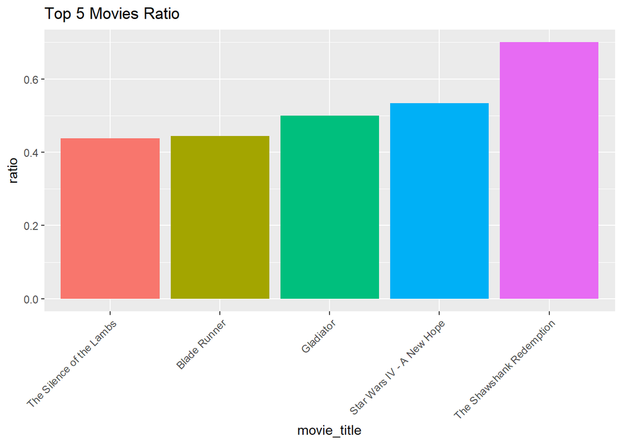

```r
# pregraph transformation:
top5ratio$movie_title <- reorder(top5ratio$movie_title, top5ratio$ratio) ## the columns in ascending order
#plot

graph_top5ratio = ggplot(data = top5ratio) + geom_col(aes(x = movie_title, y= ratio, fill = movie_title),show.legend = F) + labs(title = "Top 5 Movies Ratio") + theme(axis.text.x = element_text(angle = 45, hjust = 1))

#print result:
print(graph_top5ratio)
```

# 3) Top 5 Movies, by quantity of ratings

Count the number of ratings for each movie, order the one with most number of ratings first, submit the top 5.

**Expected result**: 17, ‘Toy Story’ 16, ‘The Silence of the Lambs’ 15, ‘Star Wars IV - A New Hope’ 14, ‘Star Wars VI - Return of the Jedi’ 13, ‘Independence Day’

first, let’s found the number of time (count) that each movie appears

```r
count = sapply(data[2:col_number] , function(x){length(x[!is.na(x)])}, simplify = T )
df_counting = data.table(as.data.frame(count), keep.rownames = T) #transform into a dataframe
```

Using the ftop5 function to find the top5

```r
#calling ftop5 function:
top5count = ftop5(df_counting)

#print top5ratio
print(top5count)
```

```
##    count                       movie_title
## 1:    17                         Toy Story
## 2:    16          The Silence of the Lambs
## 3:    15         Star Wars IV - A New Hope
## 4:    14 Star Wars VI - Return of the Jedi
## 5:    13                  Independence Day
```

plot visualization:

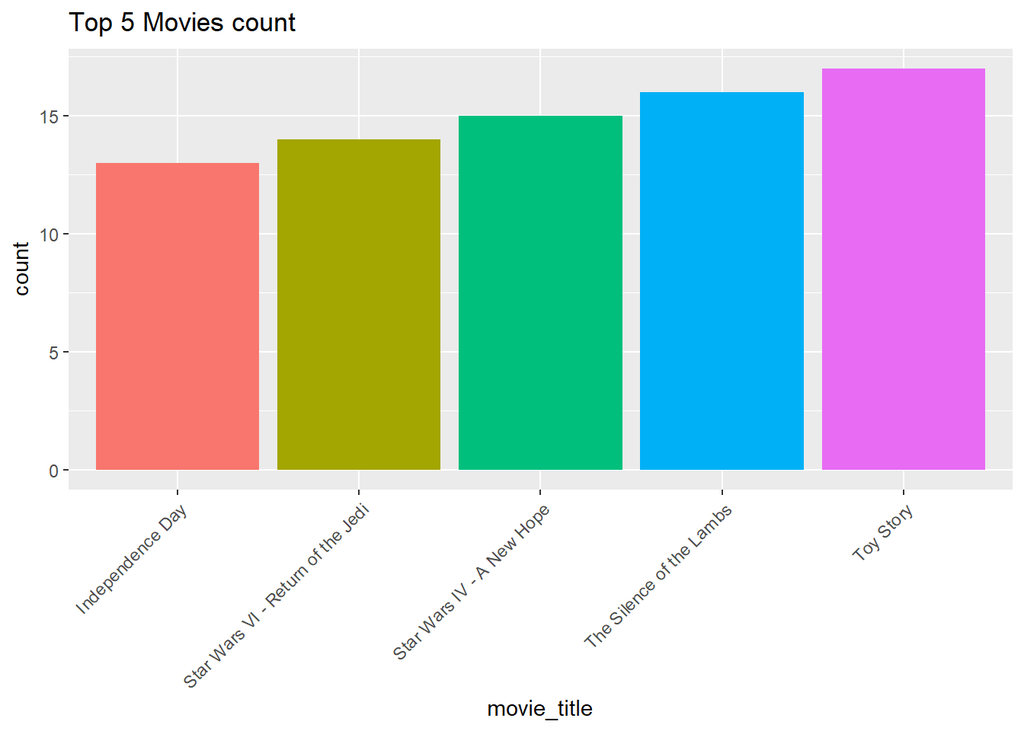

```r
# pregraph transformation:
top5count$movie_title <- reorder(top5count$movie_title, top5count$count) ## the columns in ascending order

#plot

graph_top5count = ggplot(data = top5count) + geom_col(aes(x = movie_title, y= count, fill = movie_title), show.legend = F) + labs(title = "Top 5 Movies count") + theme(axis.text.x = element_text(angle = 45, hjust = 1))

#print result:
print(graph_top5count)
```

# 4) People who watched Star Wars IV also watched …

Calculate movies that most often occur with other movie. For each movie, calculate the percentage of the other movie raters who also rated that movie. Order with the highest percentage first, and submit the top 5. Select “Star.Wars.IV…A.New.Hope” movie by defaut. Use the (x+y)/x method.

Top Occurences: 0.9333333, ‘Toy Story’ 0.8666667, ‘Star Wars: Episode VI - Return of the Jedi’ 0.8000000, ‘The Silence of the Lambs’ 0.7333333, ‘Independence Day’ 0.6666667, ‘Total Recall’

Calculating all movies that most often occur with “Star.Wars.IV…A.New.Hope”

```r
movie_na = data %>% filter(!is.na(`Star Wars IV - A New Hope`))
new_data_movie = movie_na[3: col_number]
chosen_movie = movie_na$`Star Wars IV - A New Hope`
ratio = sapply(new_data_movie, function(x){length(x[!is.na(x)]) / length(chosen_movie)})

final = data.table(as.data.frame(ratio), keep.rownames = T) #transform into a dataframe
```

Using the ftop5 function to find the top5 of the movies that often appear with “Star.Wars.IV…A.New.Hope”

```r
#calling ftop5 function:
top5SW = ftop5(final)

#print top5ratio
print(top5SW)
```

```
##        ratio                       movie_title
## 1: 0.9333333                         Toy Story
## 2: 0.8666667 Star Wars VI - Return of the Jedi
## 3: 0.8000000          The Silence of the Lambs
## 4: 0.7333333                  Independence Day
## 5: 0.6666667                      Total Recall
```

# 5) People who liked Babe also liked …

Calculate the movies better rated of people who liked a movie. Select the people who liked the movie “Babe” (4 or 5 stars) and provide the top 5 movies they liked most.

**Expected result**: 5.000, ‘Pulp.Fiction’ 5.000, ‘Groundhog.Day’ 4.500, ‘The.Shawshank.Redemption’ 4.333, ‘Toy.Story’ 4.000, ‘Blade.Runner’

Finding the rating of all the movie, then people rated ‘Babe’ 4 or 5 stars

```r
movie_babe = data %>% select(-User) %>% filter(Babe == 4 | Babe == 5)
movie_babe_not = movie_babe %>%select(-Babe)
stars = sapply(movie_babe_not, function(x){sum(x, na.rm = T) / length(x[!is.na(x)])})

df_babe = data.table(as.data.frame(stars), keep.rownames = T)
```

Using the ftop5 function to find the top5 rating movies when people like ‘Babe’

```r
#calling ftop5 function:
top5BABE = ftop5(df_babe)

#print top5ratio
print(top5BABE)
```

```
##       stars              movie_title
## 1: 5.000000             Pulp Fiction
## 2: 5.000000            Groundhog Day
## 3: 4.500000 The Shawshank Redemption
## 4: 4.333333                Toy Story
## 5: 4.000000             Blade Runner
```

# 6) MovieLens

Explore a real data set and provide non-personalized ratings. You can use the MovieLens database. You can find MovieLens’ dataset here: http://files.grouplens.org/datasets/movielens/ml-10m-README.html

Importing file

- I converted the dat file to csv format

```r
movies <- read_csv("movies.csv")
ratings <- read_csv("ratings.csv")
users <- read_csv("users.csv")
```

Giving the name to the 3 dataframes

```r
colnames(movies) = c('MovieID', 'Title', 'Genres')
colnames(ratings) = c('UserID', 'MovieID', 'Tag', 'Timestamp')
colnames(users) = c('UserID', 'Gender', 'Unkown1', 'Unkown2', 'Unkown3')
```

I did not change the Timestamp format form integer to Data because I will not use that column for the folling analysis - the same logic apply to UnkownX columns (No information availables)

- Joining the 3 dataframes
- I could use merge function (standard R function), But I like to work with SQL, therefore I will import sqldf library

```r
library(sqldf)
```

Joining table

```r
movielens = sqldf("Select * from movies
                  JOIN ratings USING(MovieID)
                  JOIN users USING(UserID)")
head(movielens, n=2)
```

```
##   MovieID          Title                        Genres UserID Tag
## 1       2 Jumanji (1995) Adventure|Children's|Fantasy;     10   5
## 2       2 Jumanji (1995) Adventure|Children's|Fantasy;     13   3
##   Timestamp Gender Unkown1 Unkown2 Unkown3
## 1 979168267      F      35       1   95370
## 2 978202563      M      45       1   93304
```

Remove unnecessary columns

```r
movielens = subset(movielens, select =-c(6,8:10))
head(movielens, n=2)
```

```
##   MovieID          Title                        Genres UserID Tag Gender
## 1       2 Jumanji (1995) Adventure|Children's|Fantasy;     10   5      F
## 2       2 Jumanji (1995) Adventure|Children's|Fantasy;     13   3      M
```

#### Now that I have reshaped the dataframe, I will answer few questions:

- Top 5 Movies, by rating mean and gender

```r
#top 5 for female
movielens_top5 = movielens %>% filter(Gender == 'F') %>% group_by(Title) %>% summarise(avg_rating = mean(Tag)) %>% arrange(desc(avg_rating)) %>%head(., n=5)
movielens_top5
```

```
## # A tibble: 5 x 2
##                              Title avg_rating
##                              <chr>      <dbl>
## 1   24 7: Twenty Four Seven (1997)          5
## 2 Ayn Rand: A Sense of Life (1997)          5
## 3           Battling Butler (1926)          5
## 4                     Belly (1998)          5
## 5                        Big Combo          5
```

```r
#top 5 for male
movielens_top5 = movielens %>% filter(Gender == 'M') %>% group_by(Title) %>% summarise(avg_rating = mean(Tag)) %>% arrange(desc(avg_rating)) %>%head(., n=5)
movielens_top5
```

```
## # A tibble: 5 x 2
##                     Title avg_rating
##                     <chr>      <dbl>
## 1           Angela (1995)          5
## 2                    Baby          5
## 3                   Bells          5
## 4   Dangerous Game (1993)          5
## 5 Follow the Bitch (1998)          5
```

- Find the top5 ratio according to some movie Genres

```r
library(stringr)
```

```r
fgenre = function(x){
  movielens[str_detect(movielens[,3], x),] %>% group_by(Title) %>% summarise(ratio = sum(Tag) / length(Tag)) %>% arrange(desc(ratio))
  }
```

```r
#Fantasy
head(fgenre('Fantasy'),5)
```

```
## # A tibble: 5 x 2
##                                          Title    ratio
##                                          <chr>    <dbl>
## 1    Star Wars: Episode IV - A New Hope (1977) 4.453846
## 2            E.T. the Extra-Terrestrial (1982) 3.965168
## 3                    Heavenly Creatures (1994) 3.865828
## 4 Willy Wonka and the Chocolate Factory (1971) 3.861386
## 5                                   Big (1988) 3.855705
```

```r
#Fantasy
head(fgenre('Fantasy'),5)
```

```
## # A tibble: 5 x 2
##                                          Title    ratio
##                                          <chr>    <dbl>
## 1    Star Wars: Episode IV - A New Hope (1977) 4.453846
## 2            E.T. the Extra-Terrestrial (1982) 3.965168
## 3                    Heavenly Creatures (1994) 3.865828
## 4 Willy Wonka and the Chocolate Factory (1971) 3.861386
## 5                                   Big (1988) 3.855705
```

```r
#Adventure
head(fgenre('Adventure'),5)
```

```
## # A tibble: 5 x 2
##                                       Title    ratio
##                                       <chr>    <dbl>
## 1                   Ulysses (Ulisse) (1954) 5.000000
## 2                            Sanjuro (1962) 4.608696
## 3            Raiders of the Lost Ark (1981) 4.477725
## 4 Star Wars: Episode IV - A New Hope (1977) 4.453846
## 5                 Lawrence of Arabia (1962) 4.401925
```